# Visualization I

If geom layers are a way to add our data to the graph and the `aes()` argument is telling that geom how to map aesthetics onto the layer, what exactly does it mean to “map aesthetics”? **Aesthetics** are simply the visual characteristics defining how our data will be presented: color, shape, size, as well as location. Because location is an aesthetic, this is where we can tell the geom what our `x` and `y` variables will be. Tell the geom what the data for each axis will be, and it can know where to put them, thus satisfying the most basic aesthetic–where to put stuff (the dots in our scatterplot example).

Let’s illustrate what we’ve gone over so far by plotting a scatterplot with the “miles per gallon” (`mpg`) and weight (`wt`) of the cars in our data set:

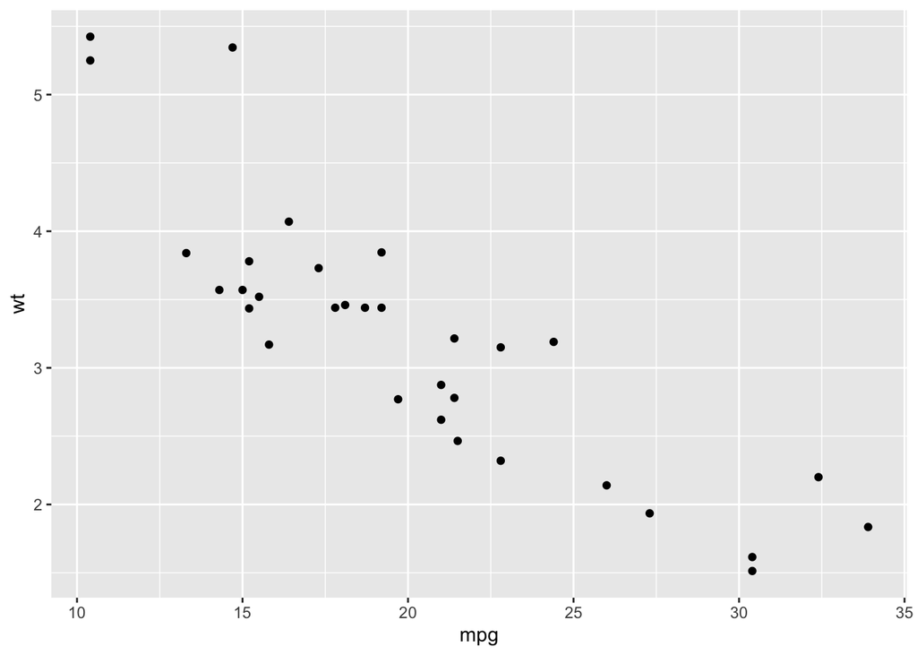

```r
ggplot(d) +
  geom_point(aes(x = mpg, y = wt))
```

Great! Now **practice** doing a scatterplot with weight (`wt`) on the y axis and 1/4 mile time (`qsec`) on the x axis. Google and the `?` operator are your best friends with ggplot. Whenever in doubt, look something up! Someone else has made every graph you can imagine.

If you only indicate the variables needed to define coordinates for your dots, they show up in the simplest way possible: usually just black. So, if we change the color, shape, or size in `aes()` that will just change how our dots look, right? Actually, no. What?? Hear me out. color, shape, and size (and a few others we’ll get to later) **within** `aes()` don’t actually take arguments like “blue”, “round”, and “small” like you might expect–the argument they take is a factor variable. But how does that work? The reason is because these aesthetics define not just what our data will look like, but *how it is organized*. The factor variables that satisfy these arguments tell the graph how to **split up** the data on the graph: boys, for example, are red dots and girls are blue dots (`color = gender`). Or, if `shape = condition`, triangles are participants in the control condition and squares are participants in the treatment condition. If `linetype = well_being_cat` in a `geom_smooth()` (i.e. high and low categories of well-being), a solid line shows the regression for those with high well-being, while a dotted line shows the regression for those with low well-being. Arguments within `aes()` tell us how to put the data on the layer, and how to organize it once it’s there. I know, I know this is super freaking confusing!!! Just keep reading and working through the code examples. Often times it’s more confusing to read paragraphs about code than code itself!

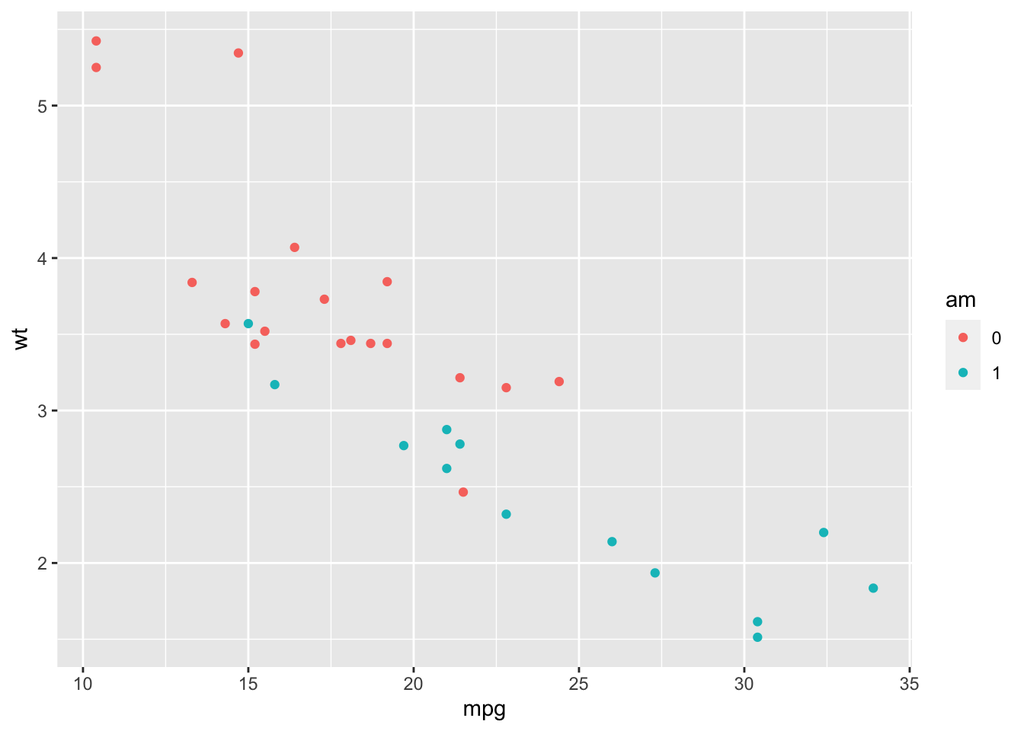

```r
ggplot(d) +
  geom_point(aes(x = mpg, y = wt, color = am))
```

So, then, if we *don’t* break our data up into groups (or even if we do), how do we control what the normal color, shape, size, etc. look like? It’s pretty simple, actually: just use each of these arguments **outside** of `aes()`. For example, geom_point(aes(x = height, y = weight, color = gender)) will show us dots for height and weight colored by gender, while geom_point(aes(x = height, y = weight), color = “green”) will color all dots for height and weight green. Herein, ggplot provides us with *lots* of flexibility with how we organize and present our data in each layer.

Here’s a comparison using our data:

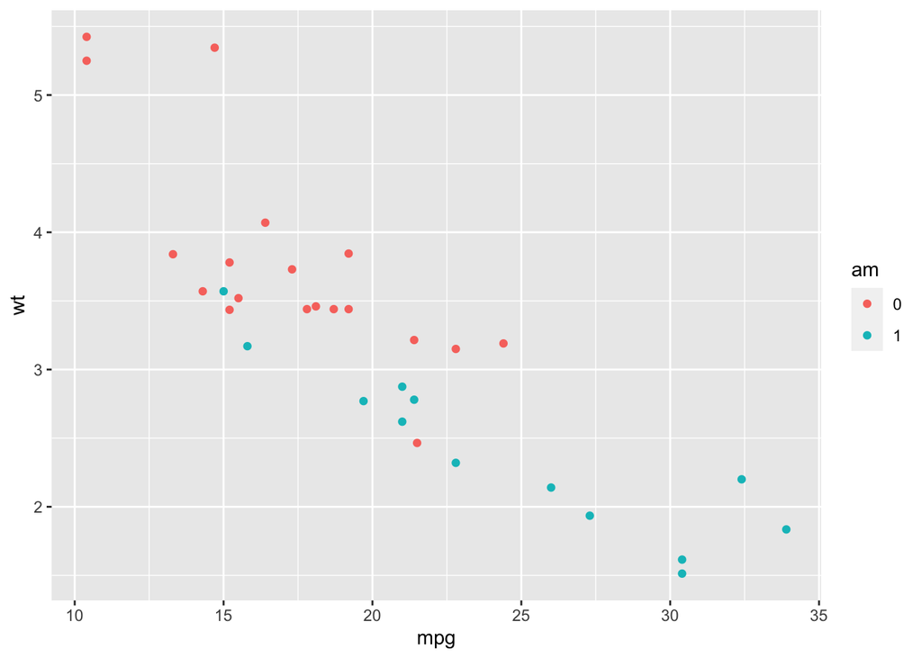

```r
ggplot(d) +
  geom_point(aes(x = mpg, y = wt, color = am))
```

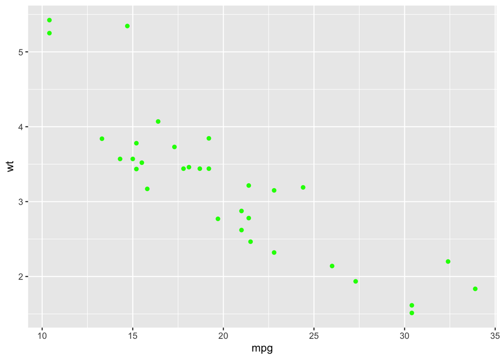

```r
ggplot(d) +
  geom_point(aes(x = mpg, y = wt), color = "green")
```

You can see that declaring the color with a variable in `aes()` matches the color to a 3rd variable, where is color outside with a color name as a string just makes everything that color!

**Practice**

Build a scatterplot with any two variables (say, `hp` and `qsec`), with the shape of the dots determined by whether the car has manual or automatic transmission (`am`). Make the points “dark green”.

One more thing: how do you add multiple layers? Easy. Like we mentioned above, you need only add a ‘+’ after one layer and then start writing the next. In this way, you can superimpose as many different geoms or other types of layers on top of each other. There is one very important detail, though, that can be easy to gloss over: *the ‘+’ has to come at the* end* (or middle) of each line of code *not* the beginning of the line of code*. Also, you may find it slightly tedious to rewrite your variables in each and every geom and layer you add to your graph. Say, using our example, you wanted a scatterplot of `mpg` and `wt`, but you also wanted to add another layer, a regression line, on top. Given what we’ve talked about so far, you may write your code for your graph like this (also pretend like we’ve already told you that adding “method = ‘lm’” is a way to make `geom_smooth` give you a regression line):

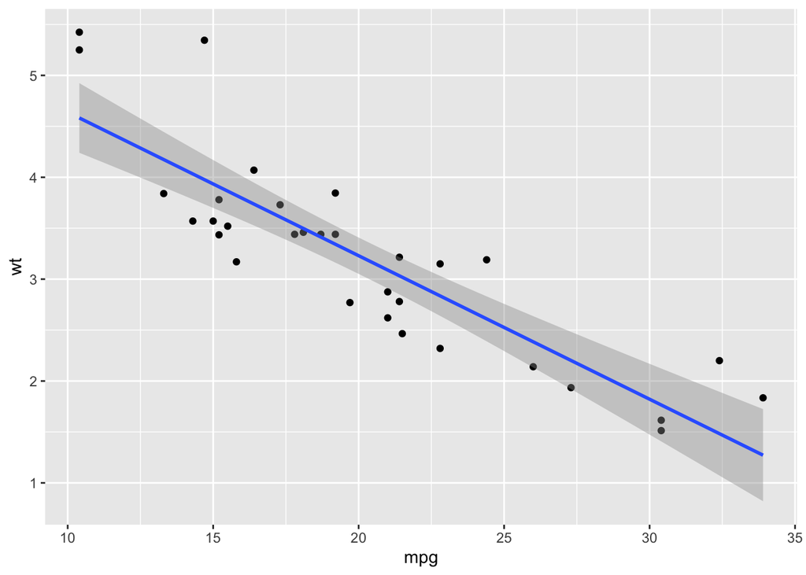

```r
ggplot(d) +
  geom_point(aes(x = mpg, y = wt)) +
  geom_smooth(aes(x = mpg, y = wt), method = "lm")
```

However, as a budding R pro, you find it a little annoying to have to write the data arguments twice over only two lines. Is there a better way to do this? I’m glad you asked…there is! While the data argument is the only argument you *need* in the main `ggplot()` function, it can also take mapping arguments–that is, `aes()`. If you add aesthetics to `ggplot()` they act as *global* aesthetics and apply to all layers, unless otherwise specified. This saves a lot of space! Similar to piping, it’s not essential to do this, but it will save you time and effort, while looking pretty :).

See how it works with our example:

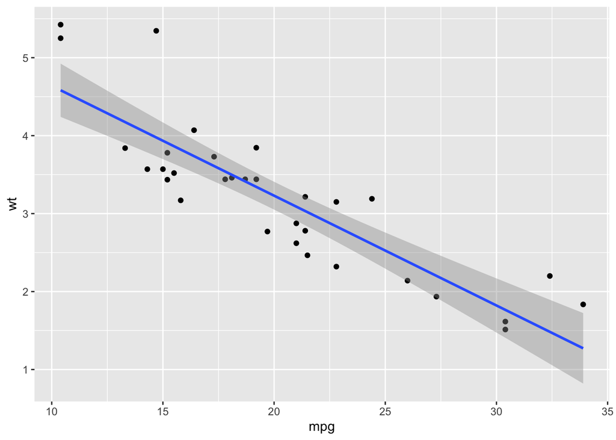

```r
ggplot(d, aes(x = mpg, y = wt)) +
  geom_point() +
  geom_smooth(method = "lm")
```

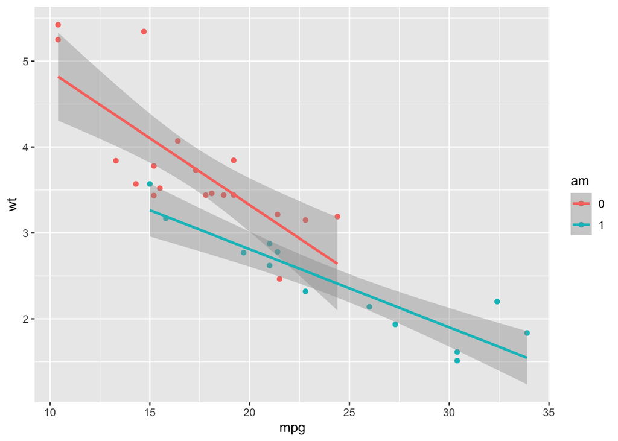

```r
ggplot(d, aes(x = mpg, y = wt, color = am)) +
  geom_point() +
  geom_smooth(method = "lm")
```

Applying global aesthetics makes it easy to provide information to `ggplot()` that will be consistent across multiple (and sometimes many) layers. Of course, there is no requirement that information *has* to be consistent–part of the power of ggplot2 is that you can use different data and aesthetics flexibly across different layers.

For example:

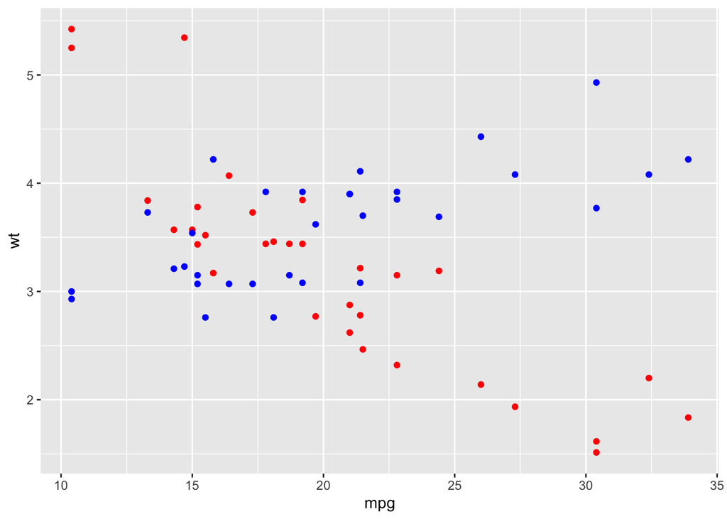

```r
ggplot(d) +
  geom_point(aes(x = mpg, y = wt), color = "red") +
  geom_point(aes(x = mpg, y = drat), color = "blue")
```

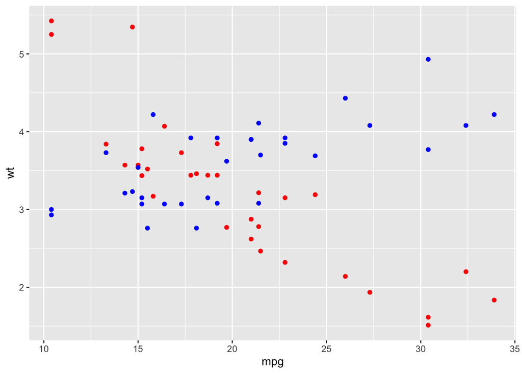

```r
#or
ggplot(d, aes(x = mpg, y = wt)) +
  geom_point(color = "red") +
  geom_point(aes(y = drat), color = "blue")
```

Note, again, as in the example above, that global aesthetics apply, unless you specify other information in a given layer. Also, note that you will need to be careful of axis labels when you have layers with different data: `ggplot()` will by default add the variables of the first layer as the axis labels.

## 2.2 Common geoms

### 2.2.1 Geoms for bivariate plots

| Geom | What It Does |
| --- | --- |
| *Bivariate plots* |  |
| `geom_point()` | to plot a scatter of data points |
| `geom_smooth()` | To plot a line of smoothed conditional means with confidence intervals (e.g. fitted regression line) |
| `geom_line()` | To plot a line graph |
| `geom_col()` | To plot a bar graph–height representing values in a y variable |

FYI, there are a TON of geom functions. Whenever in doubt, head here: [here](https://www.rstudio.com/resources/cheatsheets/). Go to the Data Visualization Cheatsheet about 1/3 of the way down the page.

First, we’ll make a couple of our variables into factors so that we can use them more easily:

```r
d %<>% mutate(
      gear = factor(gear),
      am = factor(am),
      foreign = factor(foreign),
      vs = factor(vs),
      cyl = factor(cyl))
```

#### 2.2.1.1 No need to aggregate: Point and Smooth

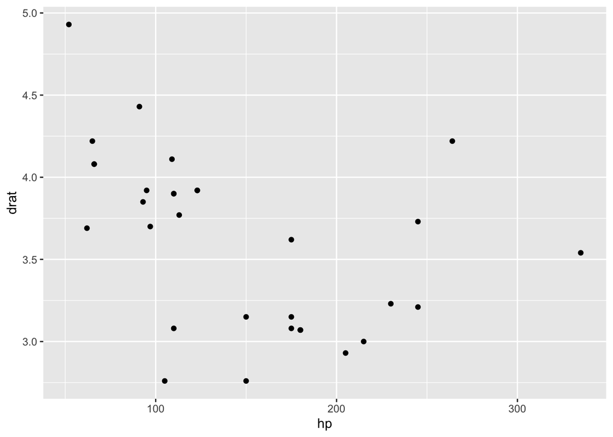

```r
# geom_point
d %>%
ggplot() +
  geom_point(aes(x = hp, y = drat))
```

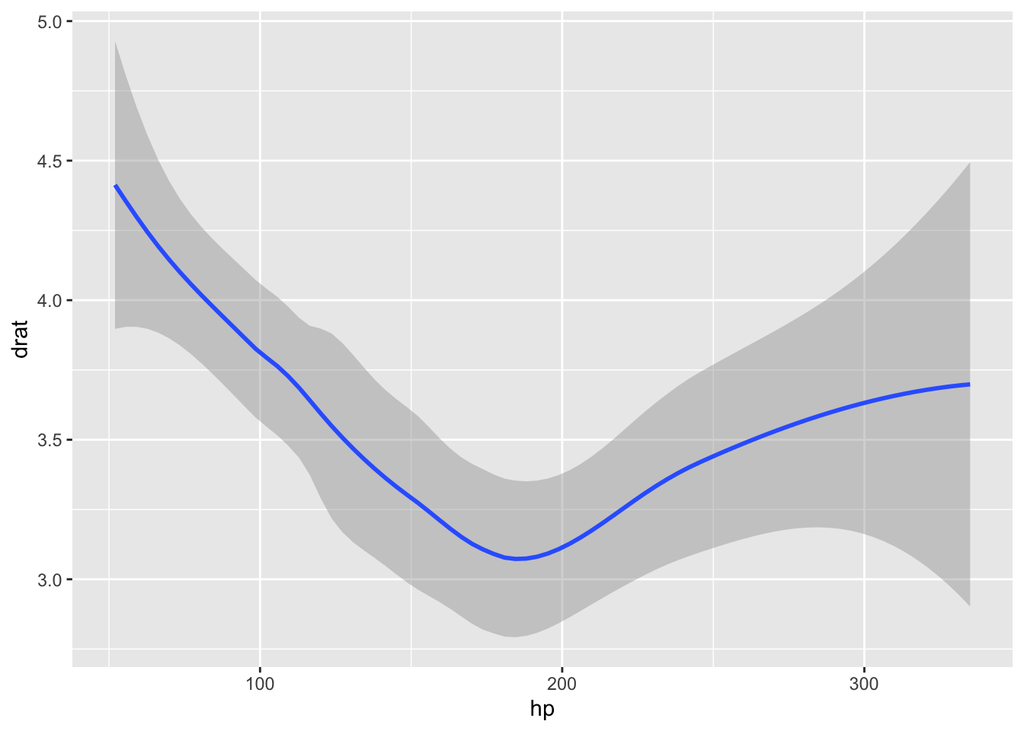

```r
# geom_smooth (smoothed conditional means with confidence intervals)
d %>%
ggplot() +
  geom_smooth(aes(x = hp, y = drat))
```

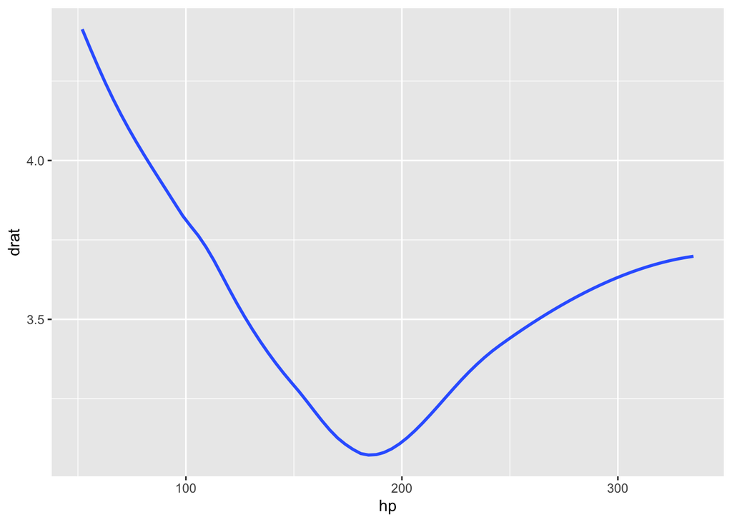

```r
# geom_smooth (smoothed conditional means without confidence intervals)
d %>%
ggplot() +
  geom_smooth(aes(x = hp, y = drat), se = FALSE)
```

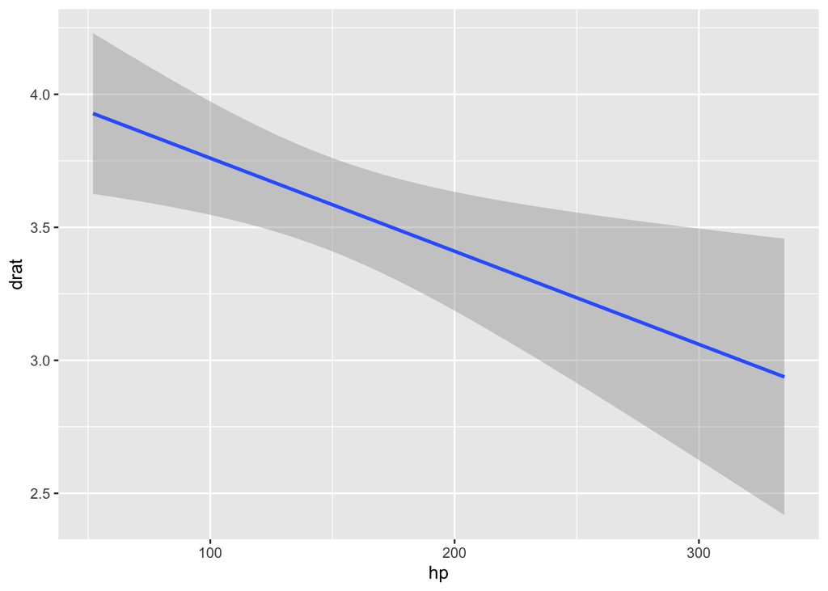

```r
# geom_smooth (fitted regression line with confidence intervals)
d %>%
ggplot() +
  geom_smooth(aes(x = hp, y = drat), method = "lm")
```

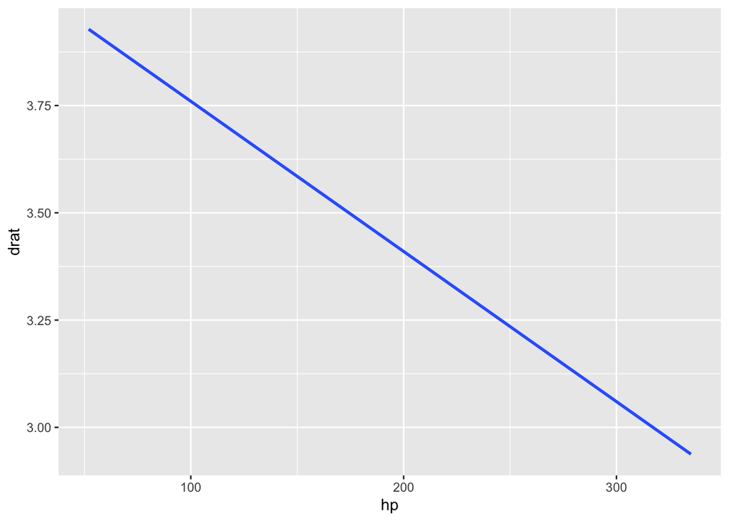

```r
# geom_smooth (fitted regression line without confidence intervals)
d %>%
ggplot() +
  geom_smooth(aes(x = hp, y = drat), method = "lm", se = FALSE)
```

**Practice**

Build a scatterplot using any two continuous variables, set the shape of the dots and the line type to any categorical variable. Add regression lines without confidence intervals. Make the dots and lines be dark red. Make the lines be thin (use the size argument, just like you would color, and set it to a number less than 1).

#### 2.2.1.2 Lines and Bars: some aggregation needed

To use geom_line() and geom_col(), we may often want to aggregate our data into means first.

```r
d_means <- d %>%
            group_by(cyl) %>%
            summarise(hp_mean = mean(hp, na.rm = TRUE), hp_sd = sd(hp, na.rm = TRUE))
```

Because these types of graphs are often used for comparing means across groups, we can use `group_by()` and `summarise()` to create a new data set of only means across groups for our variable of interest.

Now let’s use this new data set to graph how horsepower (`hp`) changes as the number of cylinders (`cyl`) increases:

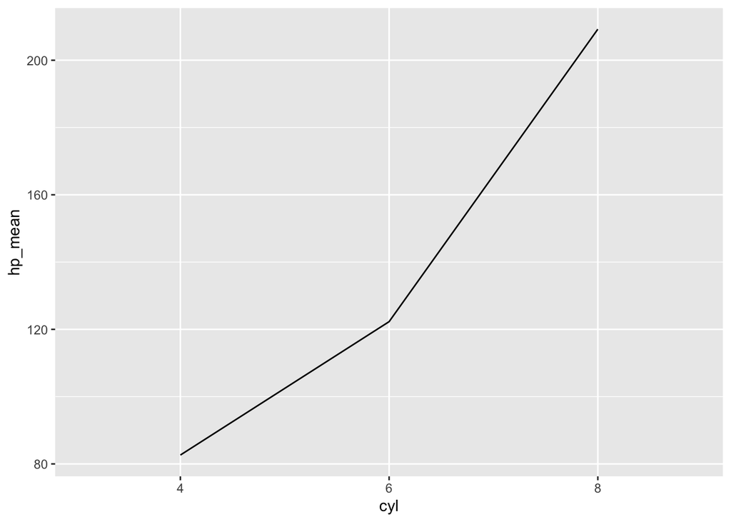

```r
d_means %>%
ggplot() +
  geom_line(aes(x = cyl, y = hp_mean, group = 1))
```

You may also want to add a `geom_point()` layer to emphasize the mean values for each level of cylinder:

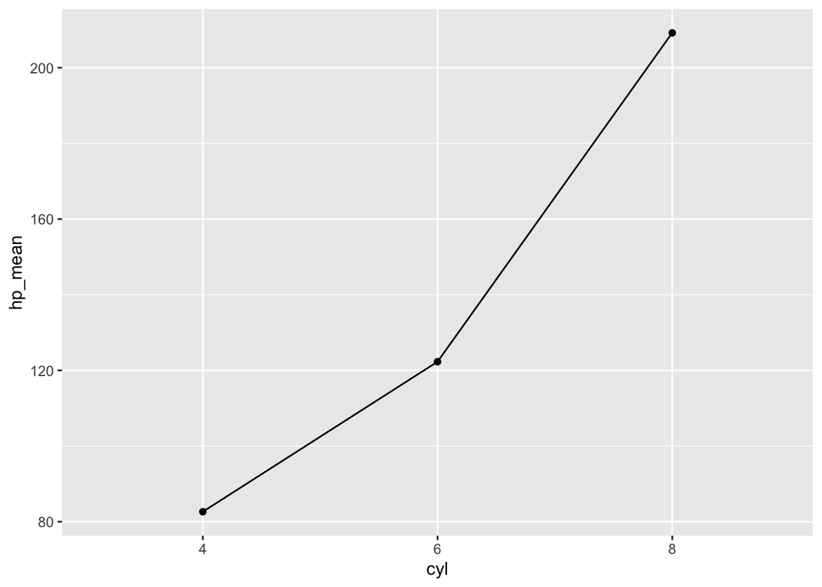

```r
d_means %>%
ggplot(aes(x = cyl, y = hp_mean, group = 1)) +
  geom_point()+
  geom_line()
```

You may have noticed we included the code “group = 1” in the aesthetic for `geom_line()`. Why? Let’s see what happens when we *don’t* do this:

```
## geom_path: Each group consists of only one observation. Do you need to adjust
## the group aesthetic?
```

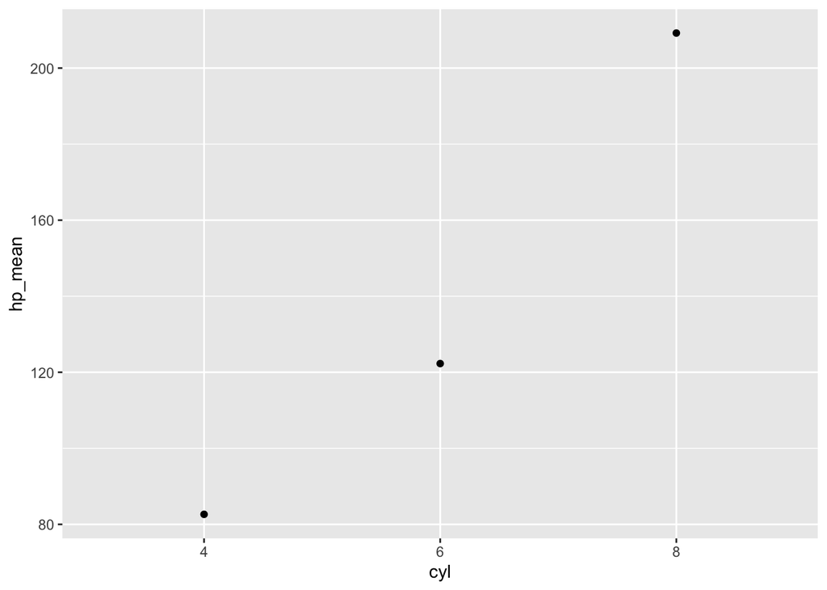

```r
d_means %>%
ggplot(aes(x = cyl, y = hp_mean)) +
  geom_point()+
  geom_line()
```

You actually get a message that says, “geom_path: Each group consists of only one observation. Do you need to adjust the group aesthetic?”

What does this mean?

The key concept is “group” in `aes()`. The rule is simple:

1. `geom_line()` tries to connect data points that belong to same group.
2. Different levels of factor variables are understood by `geom_line()` as different groups.

So, by specifying “group = 1” in `aes()`, we tell `geom_line()` to treat the points as being part of the same group, and thus to connect them. Alternatively, if you *do* want to create separate lines for different groups, you can put the grouping variable in place of “1” (e.g. “group = gender”).

Additionally, you can add error bars to show the degree of variation surrounding each mean using a geom called `geom_errorbar()`. Note that `geom_errorbar()` needs at least two arguments: the extent to which the variation spans above (`ymax`) and below (`ymin`) the mean. Here, we are just adding one standard deviation above and below the mean. If you were using estimated means from a statistical analysis, we could show standard error bars instead of standard deviations (we’ll get to how to do that in a later workshop).

Let’s take a look at how to create error bars for +/- 1 standard deviation:

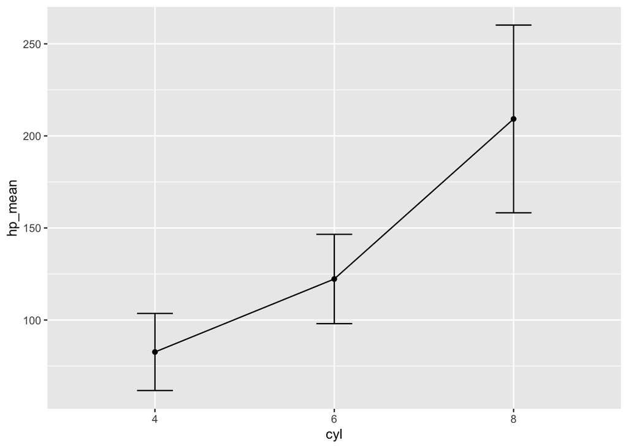

```r
d_means %>%
ggplot(aes(x = cyl, y = hp_mean, group = 1)) +
  geom_point()+
  geom_line()+
  geom_errorbar(aes(ymin=hp_mean-hp_sd, ymax=hp_mean+hp_sd), width=.2)
```

How cool is that! The `+` in ggplot is starting to feel more intuitive - ya? One literally adds and takes away features from a ggplot. LITERALLY! I’ll be honest, I’m a little sleepy as I’m writing this - I was up until 3 am cleaning the squirrels in my taxidermy set (JK JK), but I don’t have many jokes! Consider this your week off the <sub>Ben</sub> comedy :(.

**Practice**

Make a line graph where you compare the median (use the median() function) level of miles per gallon depending on the number of gears the car has. Make error bars represent the iqr (use the IQR() function) of the data

Now let’s look at a bar chart using the same variables:

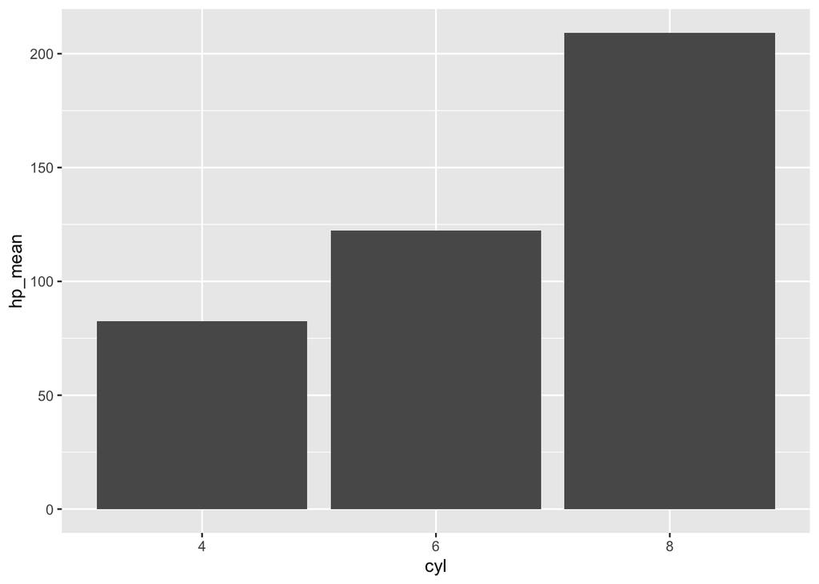

```r
d_means %>%
ggplot() +
  geom_col(aes(x = cyl, y = hp_mean))
```

And apply the same error bars:

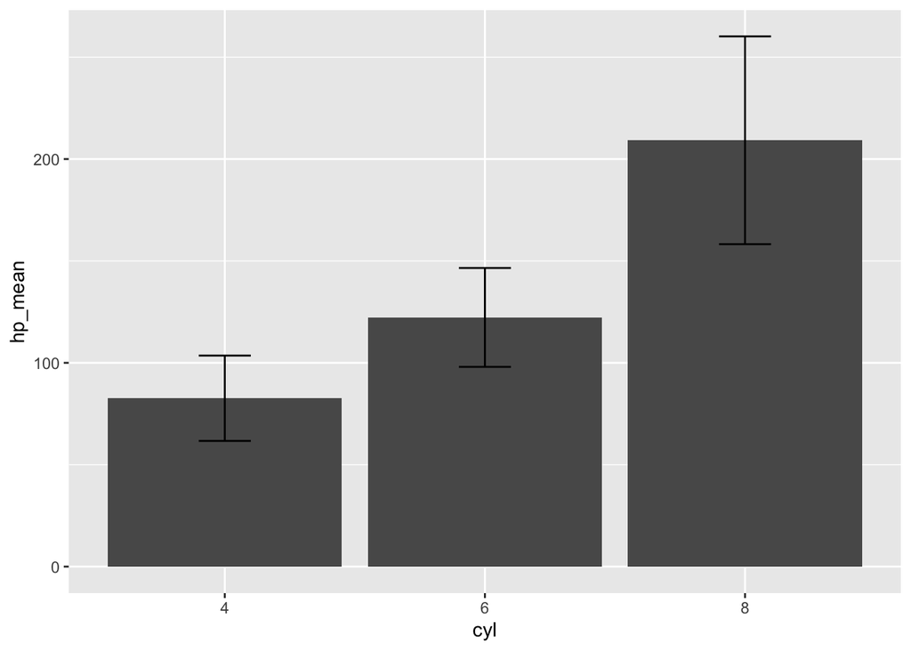

```r
d_means %>%
ggplot(aes(x = cyl, y = hp_mean)) +
  geom_col() +
  geom_errorbar(aes(ymin=hp_mean-hp_sd, ymax=hp_mean+hp_sd), width=.2)
```

**Practice**

Within V shaped engine cars (vs = 0; ), make a column chart of the mean weight of manual and automatic cars. Make the errorbars span the whole range of the distribution (they start at the weight of the lightest car and end on the weight of the heaviest). Hint: calculate these with min() and max() inside the summarize function.

We will go into more depth into visualizations and ggplot the next workshop, so hang tight!

# 3 Review: End Notes

Today, we covered:

```
*The basic structure of ggplots
*Common aesthetics
*Common geoms
*How to change the presentation of your ggplot
```

## 3.1 What’s an R Markdown again?

This is the main kind of document that I use in RStudio, and I think its one of the primary advantage of RStudio over base R console. R Markdown allows you to create a file with a mix of R code and regular text, which is useful if you want to have explanations of your code alongside the code itself. This document, for example, is an R Markdown document. It is also useful because you can export your R Markdown file to an html page or a pdf, which comes in handy when you want to share your code or a report of your analyses to someone who doesn’t have R. If you’re interested in learning more about the functionality of R Markdown, you can visit [this webpage](https://rmarkdown.rstudio.com/lesson-1.html)

You can run lines of code by highlighting them, and pressing COMMAND + ENTER on Mac, or CONTROL + ENTER on PC. If you want to run a whole chunk of code, you can press COMMAND + SHIFT + RETURN on Mac, or ALT + CONTROL + ALT + C on PC. Alternatively, you can run a chunk of code by clicking the green right-facing arrow at the top-right corner of each chunk. The downward-facing arrow directly left of the green arrow will run all code up to that point.

## 3.2 Some useful resources to continue your learning

A useful resource, in my opinion, is the [stackoverflow](http://stackoverflow.com/) website. Because this is a general-purpose resource for programming help, it will be useful to use the R tag (`[R]`) in your queries. A related resource is the [statistics stackexchange](http://stats.stackexchange.com/), which is like Stack Overflow but focused more on the underlying statistical issues.